# Interactive ML Model Building App

December 21, 2024

## Slide 1: Introducing the App

**Unlocking Insights with Interactive Modeling**

A powerful Shiny app for building, evaluating, and understanding linear regression and decision tree models.

[Link to App](https://ml73o6-mohammed-teslim.shinyapps.io/machinelearning_app/) | [Link to GitHub Repository](https://github.com/Tescoh/Developing-Data-Product.git) - procced to the folder named MachineLearning App

## Slide 2: Problem & Solution

**The Challenge:**

- Understanding and applying statistical models can be complex.
- Traditional tools often lack interactivity and visual aids.

**Our Solution:**

- An intuitive Shiny app that simplifies model building.
- Interactive controls for dataset and variable selection.
- Visualizations to aid in model interpretation and evaluation.

## Slide 3: App Features - Interactive Controls

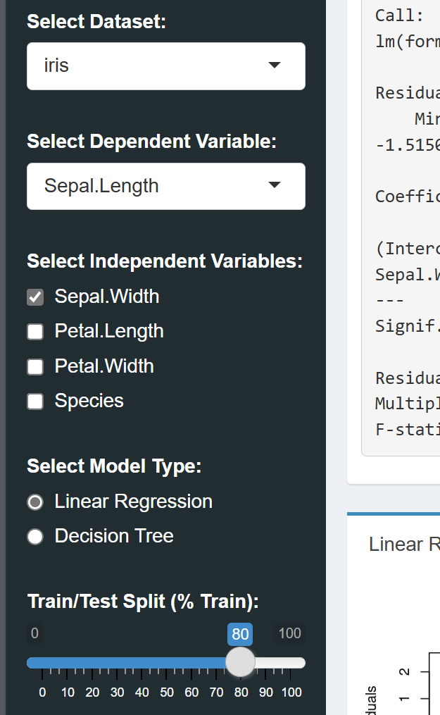

**Explore Data & Build Models:**

- Select from multiple datasets (`mtcars`, `iris`, `Boston`).
- Choose dependent & independent variables.
- Select model type (Linear Regression or Decision Tree).
- Adjust train/test split.
- Train models with 10-fold cross-validation.

## Slide 4: App Features - Results & Diagnostics

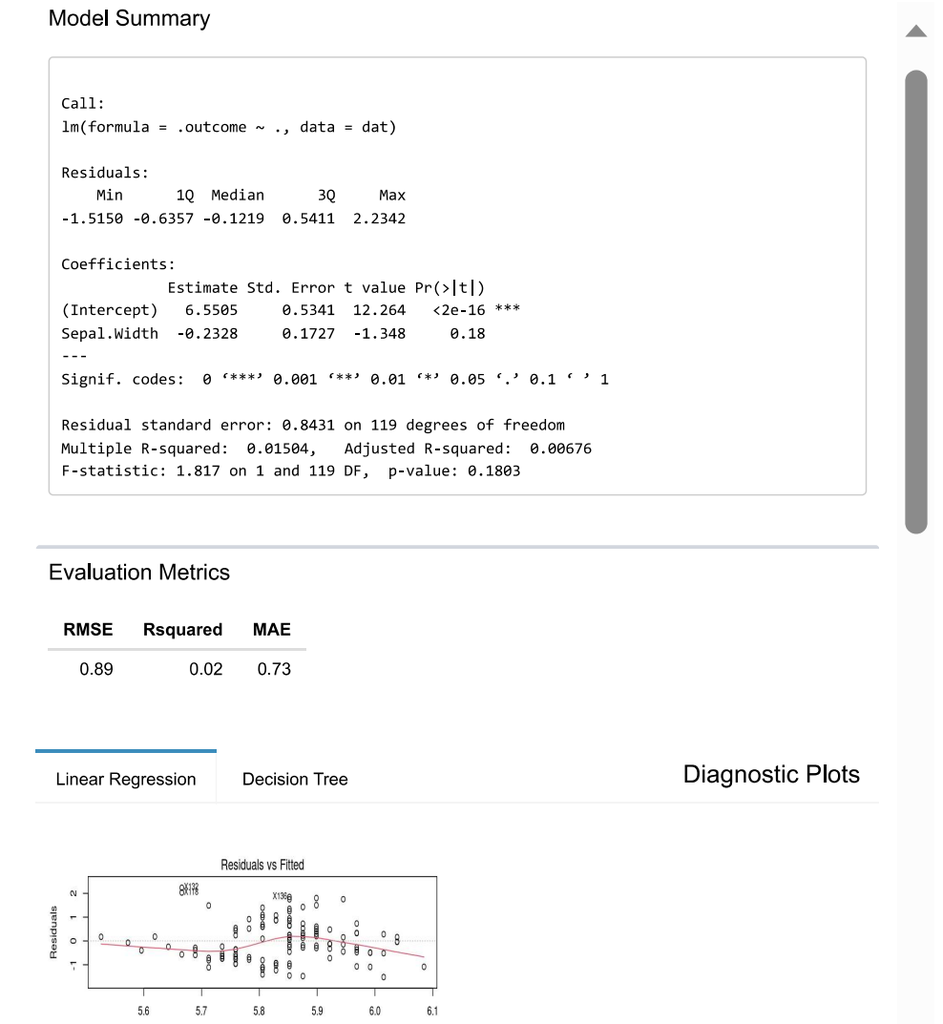

**Understand & Evaluate:**

- Detailed model summaries.
- Key evaluation metrics (R-squared, RMSE, MAE, Accuracy, Precision, Recall, F1).
- Diagnostic plots for model assessment:
  - Linear Regression: Residual plots, Q-Q plots.
  - Decision Tree: Tree visualization, variable importance.

## Slide 5: Live Demo & Call to Action

**Experience the App:**

[Link to App](https://ml73o6-mohammed-teslim.shinyapps.io/machinelearning_app)

**Explore the Code:**

[Link to GitHub Repository](https://github.com/Tescoh/Developing-Data-Product.git)

**Get Involved:**

- Try the app and provide feedback!
- Contribute to the project on GitHub.